# Introduction

```python
df['Primary_Genre'].info()
```

```
<class 'pandas.core.series.Series'>
RangeIndex: 1230376 entries, 0 to 1230375
Series name: Primary_Genre
Non-Null Count    Dtype
--------------    -----
1230376 non-null  object
dtypes: object(1)
memory usage: 9.4+ MB
```

```python
df['App_Id'].info()
df['App_Id'].dtype
```

```
<class 'pandas.core.series.Series'>
RangeIndex: 1230376 entries, 0 to 1230375
Series name: App_Id
Non-Null Count    Dtype
--------------    -----
1230376 non-null  object
dtypes: object(1)
memory usage: 9.4+ MB
```

```
dtype('O')
```

```python
df['App_Name'].info()
```

```
<class 'pandas.core.series.Series'>
RangeIndex: 1230376 entries, 0 to 1230375
Series name: App_Name
Non-Null Count    Dtype
--------------    -----
1230375 non-null  object
dtypes: object(1)
memory usage: 9.4+ MB
```

```python
df['AppStore_Url'].info()
```

```
<class 'pandas.core.series.Series'>
RangeIndex: 1230376 entries, 0 to 1230375
Series name: AppStore_Url
Non-Null Count    Dtype
--------------    -----
1230376 non-null  object
dtypes: object(1)
memory usage: 9.4+ MB
```

```python
df.duplicated()
```

```
0          False
1          False
2          False
3          False
4          False
           ...
1230371    False
1230372    False
1230373    False
1230374    False
1230375    False
Length: 1230376, dtype: bool
```

```python
df['AppStore_Url'].info()
```

```
<class 'pandas.core.series.Series'>
RangeIndex: 1230376 entries, 0 to 1230375
Series name: AppStore_Url
Non-Null Count    Dtype
--------------    -----
1230376 non-null  object
dtypes: object(1)
memory usage: 9.4+ MB
```

```python
df['AppStore_Url'].duplicated().sum()
```

```
np.int64(0)
```

```python
df['Primary_Genre'].info()
```

```
<class 'pandas.core.series.Series'>
RangeIndex: 1230376 entries, 0 to 1230375
Series name: Primary_Genre
Non-Null Count    Dtype
--------------    -----
1230376 non-null  object
dtypes: object(1)
memory usage: 9.4+ MB
```

```python
df['Primary_Genre'].duplicated().sum()
```

```
np.int64(1230350)
```

```python
df['Primary_Genre'].value_counts()
```

```
Primary_Genre
Games                     193749
Business                  128297
Education                 119174
Utilities                  94007
Lifestyle                  84565
Food & Drink               73157
Health & Fitness           60724
Productivity               59430
Entertainment              53147
Shopping                   49537
Finance                    44984
Travel                     43726
Sports                     31455
Music                      29898
Medical                    27995
Photo & Video              25957
Social Networking          25429
News                       20423
Reference                  18615
Navigation                 12636
Stickers                   12407
Book                       11472
Weather                     3563
Graphics & Design           2781
Developer Tools             1951
Magazines & Newspapers      1297
Name: count, dtype: int64
```

```python
import plotly.express as px
```

```python
import plotly.express as px

# Create a histogram
fig = px.histogram(df,
                   x='Primary_Genre',
                   category_orders={'Primary_Genre': df['Primary_Genre'].value_counts().index.tolist()},
                   text_auto=True,
                   color='Primary_Genre',
                   width=500,
                   height=800,)

# Show the figure
fig.show()
```

[output not shown]

```python
df['Content_Rating'].info()
df['Content_Rating'].duplicated().sum()
```

```
<class 'pandas.core.series.Series'>
RangeIndex: 1230376 entries, 0 to 1230375
Series name: Content_Rating
Non-Null Count    Dtype
--------------    -----
1230376 non-null  object
dtypes: object(1)
memory usage: 9.4+ MB
```

```
np.int64(1230371)
```

```python
df['Content_Rating'].unique()
```

```
array(['4+', '17+', '9+', '12+', 'Not yet rated'], dtype=object)
```

```python
df['Content_Rating'].value_counts()
```

```
Content_Rating
4+               980971
17+              124127
12+               89570
9+                35698
Not yet rated        10
Name: count, dtype: int64
```

```python
df.rename(columns={'Size_Bytes': 'Size_Mb'}, inplace=True)
```

```python
df['Size_Mb']=df['Size_Mb']/1048676
```

```python
df['Size_Mb'].info()
```

```
<class 'pandas.core.series.Series'>
RangeIndex: 1230376 entries, 0 to 1230375
Series name: Size_Mb
Non-Null Count    Dtype
--------------    -----
1230376 non-null  float64
dtypes: float64(1)
memory usage: 9.4 MB
```

```python
df['Size_Mb'].duplicated().sum()
```

```
np.int64(974461)
```

```python
df['Size_Mb'].max()
```

```
np.float64(73215.60933977702)
```

```python
df['Size_Mb'].min()
```

```
np.float64(0.026345601501321668)
```

```python
df['Size_Mb'].mean()
```

```
np.float64(71.62228472153986)
```

```python
df['Size_Mb'].median()
```

```
np.float64(41.33199577371848)
```

```python
df['Size_Mb'].mode()
```

```
0    71.622285
Name: Size_Mb, dtype: float64
```

```python
df['Required_IOS_Version'].info()
```

```
<class 'pandas.core.series.Series'>
RangeIndex: 1230376 entries, 0 to 1230375
Series name: Required_IOS_Version
Non-Null Count    Dtype
--------------    -----
1230376 non-null  object
dtypes: object(1)
memory usage: 9.4+ MB
```

```python
df['Required_IOS_Version'].duplicated().sum()
```

```
np.int64(1230116)
```

```python
df['Released'].info()
```

```
<class 'pandas.core.series.Series'>
RangeIndex: 1230376 entries, 0 to 1230375
Series name: Released
Non-Null Count    Dtype
--------------    -----
1230373 non-null  object
dtypes: object(1)
memory usage: 9.4+ MB
```

```python
df['Released'].head()
```

```
0    2017-09-28T03:02:41Z
1    2015-08-31T19:31:32Z
2    2021-04-14T07:00:00Z
3    2012-02-10T03:40:07Z
4    2020-12-16T08:00:00Z
Name: Released, dtype: object
```

```python
df['Released'].fillna(df['Released'].mode()[0],inplace=True)
```

```python
df['Released'].isnull().sum()
```

```
np.int64(0)
```

```python
df['Released'].duplicated().sum()
```

```
np.int64(565552)
```

```python
# Convert the 'Released' column to datetime format
df['Released'] = pd.to_datetime(df['Released'])

# Define a function to convert the datetime to the desired format
def convert_datetime_format(dt):
    return dt.strftime('%B %d, %Y, %I:%M %p UTC')

# Apply the function to the 'Released' column
df['Released'] = df['Released'].apply(convert_datetime_format)
```

```python
df['Released'].head(5)
```

```
0    September 28, 2017, 03:02 AM UTC
1       August 31, 2015, 07:31 PM UTC
2        April 14, 2021, 07:00 AM UTC
3     February 10, 2012, 03:40 AM UTC
4     December 16, 2020, 08:00 AM UTC
Name: Released, dtype: object
```

```python
df['Updated'].info()
```

```
<class 'pandas.core.series.Series'>
RangeIndex: 1230376 entries, 0 to 1230375
Series name: Updated
Non-Null Count    Dtype
--------------    -----
1230376 non-null  object
dtypes: object(1)
memory usage: 9.4+ MB
```

```python
df['Updated'].duplicated().sum()
```

```
np.int64(34323)
```

```python
df['Updated'].head()
```

```
0    2018-12-21T21:30:36Z
1    2019-07-23T20:31:09Z
2    2021-05-30T21:08:54Z
3    2019-10-29T12:40:37Z
4    2020-12-18T21:36:11Z
Name: Updated, dtype: object
```

```python
# Convert the 'Updated' column to datetime format
df['Updated'] = pd.to_datetime(df['Updated'])

# Define a function to convert the datetime to the desired format
def convert_datetime_format(dt):
    return dt.strftime('%B %d, %Y, %I:%M %p UTC')

# Apply the function to the 'Updated' column
df['Updated'] = df['Updated'].apply(convert_datetime_format)
```

```python
df['Updated'].head()
```

```
0    December 21, 2018, 09:30 PM UTC
1        July 23, 2019, 08:31 PM UTC
2         May 30, 2021, 09:08 PM UTC
3     October 29, 2019, 12:40 PM UTC
4    December 18, 2020, 09:36 PM UTC
Name: Updated, dtype: object
```

```python
df['Version'].info()
```

```
<class 'pandas.core.series.Series'>
RangeIndex: 1230376 entries, 0 to 1230375
Series name: Version
Non-Null Count    Dtype
--------------    -----
1230376 non-null  object
dtypes: object(1)
memory usage: 9.4+ MB
```

```python
df['Version'].duplicated().sum()
```

```
np.int64(1189106)
```

```python
df['Version']=pd.to_numeric(df['Version'],errors='coerce')
```

```python
df['Version'].dtype
```

```
dtype('float64')
```

## Data visualization

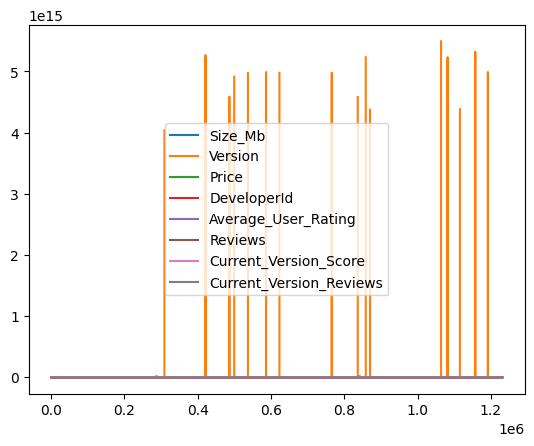

```python
df.plot()
```

#### Insights:

The graph might not be suitable for drawing direct comparisons without normalizing the data. Proper preprocessing, such as scaling or log-transformation, could help in interpreting the data. Features like Reviews and Average_User_Rating might provide valuable insights into app popularity or user satisfaction, but they are visually under-represented due to scaling issues.

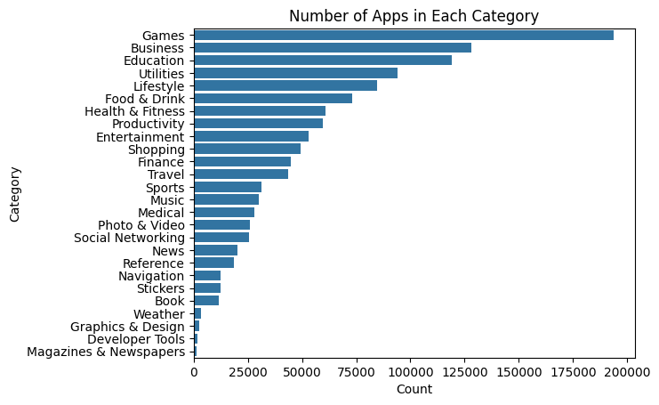

```python
#Konsi category me sabse zyada apps hain aur konsi category popular hai?#
category_counts = df['Primary_Genre'].value_counts()
sns.barplot(x=category_counts.values, y=category_counts.index)
plt.title("Number of Apps in Each Category")
plt.xlabel("Count")
plt.ylabel("Category")
plt.show()
```

The graph represents the distribution of apps across various categories in the Apple App Store, showing the number of apps available in each category.

#### Observations:

*Games:* The largest category with the highest number of apps, showcasing the dominance of gaming in the App Store. *Business, Education, and Utilities:* These categories also have a significant number of apps, indicating high demand for productivity and learning tools. *Niche Categories:* Categories such as Graphics & Design, Developer Tools, and Magazines & Newspapers have comparatively fewer apps, reflecting their specialized nature. *Insights on App Trends:* Entertainment-related categories such as Games, Lifestyle, and Entertainment dominate the App Store. Categories like Medical and Weather have fewer apps, likely because they cater to specific needs or require domain-specific expertise.

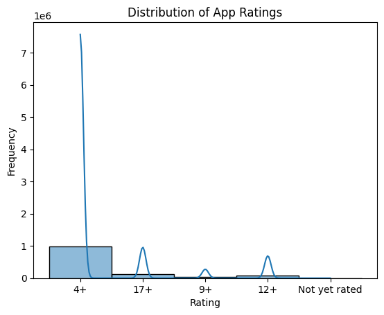

```python
# Average rating kya hai? Ratings ka variation kaisa hai? Zyada apps high-rated hain ya low-rated?
sns.histplot(df['Content_Rating'], bins=20, kde=True)
plt.title("Distribution of App Ratings")
plt.xlabel("Rating")
plt.ylabel("Frequency")
plt.show()
```

#### Observations:

*4+ Rating Dominance:* The majority of apps fall under the 4+ rating, indicating that most apps are suitable for general audiences. *Lower Counts in Higher Ratings:* Apps rated 9+, 12+, and 17+ are far fewer compared to 4+, suggesting fewer apps target older age groups. *Not Yet Rated:* A very small number of apps are unrated, implying that most apps comply with Apple's rating guidelines. *KDE Curve:* The kernel density estimate (KDE) curve highlights the concentration of apps in the 4+ category with a steep drop-off for other categories.

#### Insights:

*App Accessibility:* The Apple App Store heavily emphasizes apps that are family-friendly or suitable for younger users. *Opportunities in Higher Ratings:* There may be untapped opportunities for developers to target apps for older age groups (e.g., 12+ and 17+ ratings). *Compliance:* A negligible number of unrated apps suggest strict adherence to Apple's rating requirements.

#### Suggestions for Further Analysis:

Include subcategories within each rating (e.g., games, education) to understand trends by type. Use percentages instead of absolute frequencies for better proportional insights.

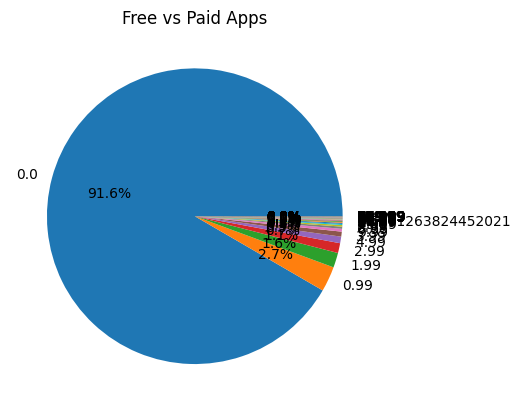

```python
# Pie Chart
free_paid_counts = df['Price'].value_counts()
plt.pie(free_paid_counts, labels=free_paid_counts.index, autopct='%1.1f%%')
plt.title("Free vs Paid Apps")
plt.show()
```

##### Dominance of Free Apps:

The chart shows that 91.6% of apps are free, indicating a significant majority in the market.

##### Small Share of Paid Apps:

Only 8.4% of apps are paid, suggesting that users prefer free options.

##### Price Range:

The paid apps have a price range shown in the chart, with the lowest price at 0.99 and some apps priced at 2.99 or 3.99.

##### User Preference:

This trend indicates that users tend to prefer downloading and using free apps, which often generate revenue through ads or in-app purchases.

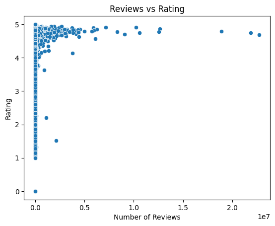

```python
sns.scatterplot(x='Reviews', y='Average_User_Rating', data=df)
plt.title("Reviews vs Rating")
plt.xlabel("Number of Reviews")
plt.ylabel("Rating")
plt.show()
```

### Reviews vs Rating Correlation

This chart show review about apps

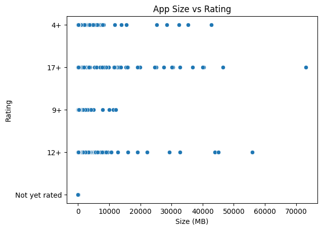

```python
sns.scatterplot(x='Size_Mb', y='Content_Rating', data=df)
plt.title("App Size vs Rating")
plt.xlabel("Size (MB)")
plt.ylabel("Rating")
plt.show()
```

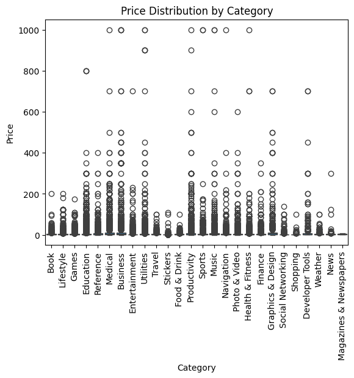

```python
sns.boxplot(x='Primary_Genre', y='Price', data=df[df['Price'] > 0])
plt.title("Price Distribution by Category")
plt.xlabel("Category")
plt.ylabel("Price")
plt.xticks(rotation=90)
plt.show()
```

### Pricing Trends

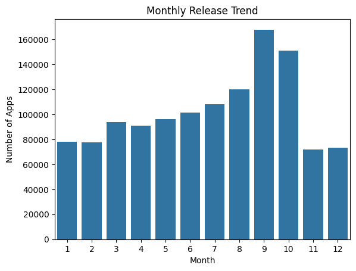

```python
# Monthly Update Trend
df['Release Month'] = pd.to_datetime(df['Updated']).dt.month
sns.countplot(x='Release Month', data=df)
plt.title("Monthly Release Trend")
plt.xlabel("Month")
plt.ylabel("Number of Apps")
plt.show()
```

```python
!pip install wordcloud
```

### Word Cloud for App Names or Descriptions

Insight: Konsi keywords common hain app names ya descriptions me?

```python
from wordcloud import WordCloud
```

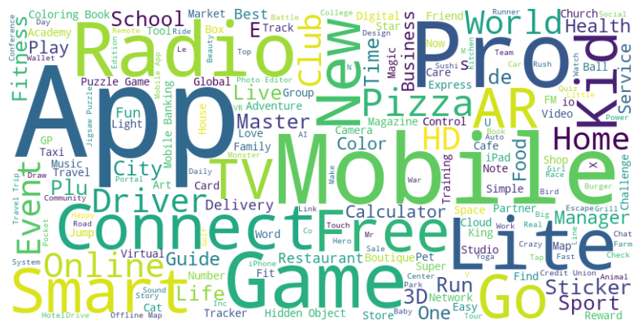

```python
text = " ".join(df['App_Name'].dropna())
wordcloud = WordCloud(width=800, height=400, background_color='white').generate(text)

plt.figure(figsize=(10, 5))
plt.imshow(wordcloud, interpolation='bilinear')
plt.axis('off')
plt.show()
```

```python
numeric_df = df.select_dtypes(include=['number'])  # Select only numeric columns
```

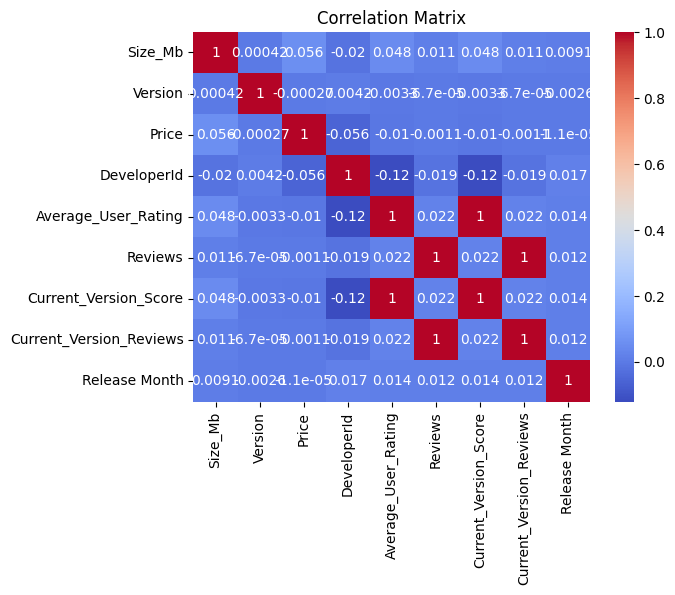

```python
sns.heatmap(numeric_df.corr(), annot=True, cmap='coolwarm')
plt.title("Correlation Matrix")
plt.show()
```